# re_stepwise

Jonathan Lanz 23-106-255

2025-04-14

```r
#load libraries
library(ggplot2)
library(tidyverse)
library(dplyr)

# load data
url_half_hourly_fluxes <- "https://raw.githubusercontent.com/geco-bern/agds_book/refs/heads/main/book/data/df_for_stepwise_regression.csv"

half_hourly_fluxes <- read.table(
  url_half_hourly_fluxes, header = TRUE, sep = ","
)
```

## 1 The FLUXNET2015 dataset

The FLUXNET2015 Dataset is a dataset that includes data about fluxes. It consists of many different variables, such as air temperature (TA_F), shortwave radiation (SW_IN_F), longwave radiation (LW_IN_F), vapor pressure deficit (VPD_F), air pressure (PA_F), precipitation (P_F), wind speed (WS_F), photosnthetic photon flux density (PPFD)_IN), global primary production (GPP_NT_VUT_REF) and friction velocity (USTAR). For this analysis, I focus on the variable GPP_NT_VUT_REF, gross primary production. The goal is to generate regression models with one other variable (predictor) in a first step, followed by a stepwise forward regression with increasing number of predictors and elaborate which is the best model.

## 2 Single predictor (bivariate) regression models

The GPP is a column in the half_hourly_fluxes dataset that indicates the gross primary production. I want to evaluate which bivariate regression model is the best, that is, find the variable that is the best single predictor for regression models.

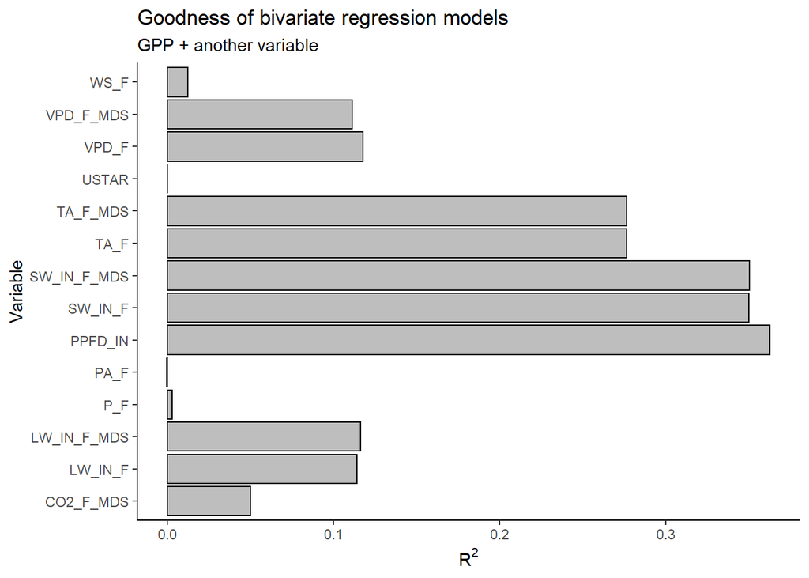

```r
# preparation
# only select the numeric values
half_hourly_fluxes_num <- half_hourly_fluxes |>
  select(-starts_with("TIMESTAMP"), -starts_with("siteid")) |>
  drop_na()

# create dataframe to store results
lm_results <- data.frame(
  predictor = character(), r2 = numeric())

# create dataframe to store predictors
predictors <- setdiff(names(half_hourly_fluxes_num), c("GPP_NT_VUT_REF"))

# fit linear regression models with different predictors
for (predictor in predictors){
  lm_formula <- as.formula(paste("GPP_NT_VUT_REF ~ ", predictor))
  linear_model <- lm(lm_formula, data = half_hourly_fluxes_num)

  # calculate R2
  r2 <- summary(linear_model)$r.squared

  # store results
  lm_results <- rbind(lm_results, data.frame(
    predictor = predictor,
    R2 = r2))
}

# plot results
barplot_lm_results <- ggplot(lm_results, aes(x = predictor, y = R2)) +
  geom_bar(stat = "identity", fill = "grey", colour="black") +
  labs(title = "Goodness of bivariate regression models", subtitle = "GPP + another variable", x = "Variable", y = expression("R"^2)) +
  coord_flip() +
  theme_classic()


barplot_lm_results
```

It can be seen that the regression model with PPFD_IN is the best. Since this variable measures the photosynthesis photon flux density (incoming light that is available for photosynthesis), it makes sense that it has a high correlation with the gross primary production, which depends directly on photosynthesis. I select this model and compute the AIC.

```r
# select the predictor with highest R2
lm_results_sorted <- lm_results |> arrange(desc(R2))
best_predictor <- lm_results_sorted$predictor[1]


# define best bivariate model
best_single_model <- lm(
  GPP_NT_VUT_REF ~ half_hourly_fluxes_num[[best_predictor]],
  data = half_hourly_fluxes_num)


# calculate AIC for best bivariate model
single_model_aic <- AIC(best_single_model)

single_model_aic
```

```
## [1] 45682.99
```

```r
best_single_model
```

```
##
## Call:
## lm(formula = GPP_NT_VUT_REF ~ half_hourly_fluxes_num[[best_predictor]],
##     data = half_hourly_fluxes_num)
##
## Coefficients:
##                              (Intercept)
##                                 0.983693
## half_hourly_fluxes_num[[best_predictor]]
##                                 0.009736
```

```r
# print R2 of best bivariate model
lm_results_sorted[1,]
```

```
##   predictor        R2
## 1   PPFD_IN 0.3627837
```

```r
lm_results_sorted
```

```
##      predictor           R2
## 1      PPFD_IN 3.627837e-01
## 2  SW_IN_F_MDS 3.504158e-01
## 3      SW_IN_F 3.503274e-01
## 4     TA_F_MDS 2.766429e-01
## 5         TA_F 2.766277e-01
## 6        VPD_F 1.179701e-01
## 7  LW_IN_F_MDS 1.163707e-01
## 8      LW_IN_F 1.142586e-01
## 9    VPD_F_MDS 1.115091e-01
## 10   CO2_F_MDS 5.012735e-02
## 11        WS_F 1.229558e-02
## 12         P_F 2.967794e-03
## 13        PA_F 2.874295e-04
## 14       USTAR 3.090633e-05
```

## 3 Stepwise forward regression

Now I execute a stepwise forward multivariate regression (i.e., regression with multiple predictors) starting with the PPFD_IN variable as the first predictor.

```r
predictors <- setdiff(names(half_hourly_fluxes_num), c("GPP_NT_VUT_REF", best_predictor))
selected_predictors <- best_predictor

current_model <- best_single_model
current_aic <- single_model_aic

stepwise_aic <- c()

max_steps <- length(predictors)

for (step in 1:max_steps) {
  step_stats <- data.frame(
    feature = character(),
    rsq = numeric()
  )

  for (predictor in predictors) {

    temp_formula <- as.formula(
      paste("GPP_NT_VUT_REF ~", paste(c(selected_predictors, predictor), collapse = "+"))
    )

    temp_model <- lm(temp_formula, data = half_hourly_fluxes_num)
    r2 <- summary(temp_model)$r.squared

    step_stats <- rbind(step_stats, data.frame(
      feature = predictor,
      rsq = r2
    ))
  }

  # Find best new predictor
  best_new_pred <- step_stats$feature[which.max(step_stats$rsq)]

  # Build new model with this variable
  updated_formula <- as.formula(
    paste("GPP_NT_VUT_REF ~", paste(c(selected_predictors, best_new_pred), collapse = "+"))
  )

  updated_model <- lm(updated_formula, data = half_hourly_fluxes_num)
  updated_aic <- AIC(updated_model)

  # Check if model is improved
  if (updated_aic < current_aic) {

    # Update current model
    current_model <- updated_model
    current_aic <- updated_aic

    # Update predictors
    selected_predictors <- c(selected_predictors, best_new_pred)
    predictors <- setdiff(predictors, best_new_pred)

    # Store progress
    stepwise_aic <- c(stepwise_aic, current_aic)
    }
  else {
    # Stop if no further improvement
    break
  }
}
```

For a better overview, let’s visualize the AIC in a graph.

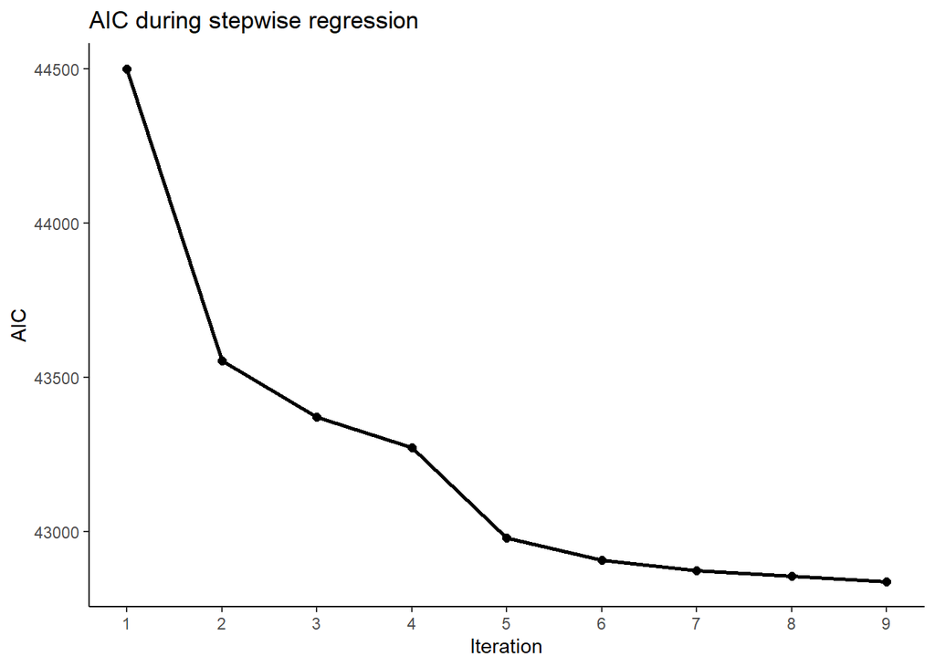

```r
aic_df <- data.frame(
  Iteration = 1:length(stepwise_aic),
  AIC = stepwise_aic
)


aic_plot <- aic_df |>
  ggplot(aes(x = Iteration, y = AIC)) +
  geom_line(linewidth = 1) +
  geom_point(size = 2) +
  labs(title = "AIC during stepwise regression", x = "Iteration", y = "AIC") +
  theme_classic() +
  scale_x_continuous(breaks = seq(1, 10, 1))

aic_plot
```

It can be seen that the expense required to improve the model is worth it until the 5th predictor (maybe 6). Including more predictors involves too much computational effort compared to the benefit, since it makes the AIC only negligibly better.